# **Pobreza y desigualdad en Uruguay**

[figure not shown]

**La [Unidad de Métodos y Acceso a Datos](https://umad.cienciassociales.edu.uy/) (UMAD) (FCS-UdelaR) a partir del [Observatorio Uruguay](https://umad.cienciassociales.edu.uy/observatorio-uruguay/) busca aportar a la difusión de conocimiento respecto a temas de interés general sobre la realidad social, económica y política del Uruguay. Esta serie de documentos tiene como objetivo presentar indicadores clave para el análisis de tendencias históricas del país que esperamos sean de utilidad para las comunidades académicas, los tomadores de decisión y los formadores de opinión, así como el público en general. Se presentan aquí indicadores sobre niveles de bienestar material de la población, ingresos, desigualdad y pobreza en el Uruguay durante las últimas décadas.**

# **Nivel de ingresos**

## **Promedio y mediana**

El ingreso de los hogares es indicativo de sus posibilidades de acceso a bienes y servicios en el mercado. El ingreso per-cápita se calcula dividiendo el total de ingresos que percibe un hogar entre la cantidad de personas que en el mismo residen.

#### **Promedio y mediana de ingresos per-cápita de los hogares (cte. base diciembre 2006)**

##### País Urbano, 1981 - 2024

#### Gráfico

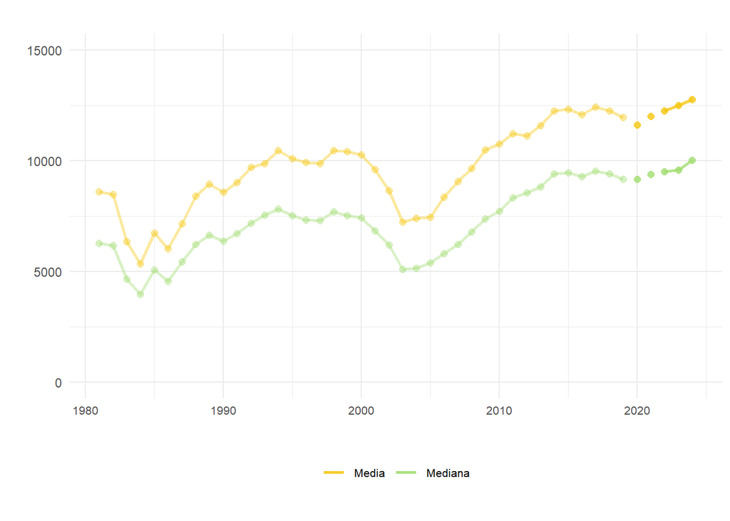

#### Tabla

|  | NOMINDICADOR | PAIS | UNIDAD_GEOGRÁFICA | ANIO | VALOR |
| --- | --- | --- | --- | --- | --- |
| 1 | Promedio de ingreso per-cápita de los hogares (Cte. Base diciembre 2006) | Uruguay | Urbano (más de 5.000 habitantes) | 1981 | 8592.5 |
| 2 | Promedio de ingreso per-cápita de los hogares (Cte. Base diciembre 2006) | Uruguay | Urbano (más de 5.000 habitantes) | 1982 | 8493.4 |
| 3 | Promedio de ingreso per-cápita de los hogares (Cte. Base diciembre 2006) | Uruguay | Urbano (más de 5.000 habitantes) | 1983 | 6336.1 |
| 4 | Promedio de ingreso per-cápita de los hogares (Cte. Base diciembre 2006) | Uruguay | Urbano (más de 5.000 habitantes) | 1984 | 5330.4 |
| 5 | Promedio de ingreso per-cápita de los hogares (Cte. Base diciembre 2006) | Uruguay | Urbano (más de 5.000 habitantes) | 1985 | 6733.2 |
| 6 | Promedio de ingreso per-cápita de los hogares (Cte. Base diciembre 2006) | Uruguay | Urbano (más de 5.000 habitantes) | 1986 | 6017.8 |
| 7 | Promedio de ingreso per-cápita de los hogares (Cte. Base diciembre 2006) | Uruguay | Urbano (más de 5.000 habitantes) | 1987 | 7154.1 |
| 8 | Promedio de ingreso per-cápita de los hogares (Cte. Base diciembre 2006) | Uruguay | Urbano (más de 5.000 habitantes) | 1988 | 8409.4 |
| 9 | Promedio de ingreso per-cápita de los hogares (Cte. Base diciembre 2006) | Uruguay | Urbano (más de 5.000 habitantes) | 1989 | 8939.2 |
| 10 | Promedio de ingreso per-cápita de los hogares (Cte. Base diciembre 2006) | Uruguay | Urbano (más de 5.000 habitantes) | 1990 | 8580.9 |

[output cut: 78 more lines]

#### Ficha Técnica

> **Definición:** El nivel de ingreso de los hogares es un indicador de su capacidad de compra y la posibilidad de satisfacción de las necesidades de los integrantes del hogar a partir de la compra de bienes y servicios.

> **Forma de cálculo:** El ingreso per-cápita se calcula como el ingreso total del hogar (valores INE) dividido la cantidad de personas del hogar. El cálculo no considera al servicio doméstico. Los valores de ingreso son constantes a diciembre 2006.

> **Advertencia:** Desde marzo de 2020 hasta junio de 2021 se interrumpió el relevamiento presencial y se aplicó de manera telefónica un cuestionario restringido con el objetivo de continuar publicando los indicadores de ingresos y mercado de trabajo. En ese período la encuesta pasó a ser de paneles rotativos elegidos al azar a partir de los casos respondentes del año anterior. En julio de 2021 el INE retomó la realización de encuestas presenciales, pero introdujo un cambio metodológico, ya que la ECH pasa a ser una encuesta de panel rotativo con periodicidad mensual compuesta por seis paneles o grupos de rotación, cada uno de los cuales es una muestra representativa de la población. Con esta nueva metodología, cada hogar seleccionado participa durante seis meses de la ECH. A partir de 2022 el indicador se calcula a partir de la base de implantación anual.

#### Código en R

```r
### Estimación de valores 2022 ###

# Para sintaxix de años anteriores consultar:
# https://osf.io/dyzg8/files/osfstorage#

# ~~~~~~~~~~~~~~~~~~~~~~~~~~~~~~~~~~~~~~~~~~~~~~~~~~~~~~~~~~~~~~~~~~~~~~~~~~~ #

### Carga de paquetes ###

# Instalar si es necesario:
#install.packages("rio")
#install.packages("srvyr")
#install.packages("tidyverse")

library(rio)
library(srvyr)
library(tidyverse)


# ~~~~~~~~~~~~~~~~~~~~~~~~~~~~~~~~~~~~~~~~~~~~~~~~~~~~~~~~~~~~~~~~~~~~~~~~~~~ #

### Descarga bases ECH 2022 (INE) de repositorio UMAD-FCS ###

#download.file(
#  url = "https://osf.io/download/rehz2/",
#  destfile = "Base anual 2022.Rdata"
#)


# ~~~~~~~~~~~~~~~~~~~~~~~~~~~~~~~~~~~~~~~~~~~~~~~~~~~~~~~~~~~~~~~~~~~~~~~~~~~ #

### Carga de bases ###

#load("Base anual 2022.Rdata")

# ~~~~~~~~~~~~~~~~~~~~~~~~~~~~~~~~~~~~~~~~~~~~~~~~~~~~~~~~~~~~~~~~~~~~~~~~~~~ #


## Generación de nuevas variables ###

#IPC

base <- base %>% dplyr::mutate(bc_ipc_tot = case_when(
  mes == 1  ~ 0.310804203,
  mes == 2  ~ 0.305354401,
  mes == 3  ~ 0.300928439,
  mes == 4  ~ 0.297635795,
  mes == 5  ~ 0.296181029,
  mes == 6  ~ 0.294810362,
  mes == 7  ~ 0.293094596,
  mes == 8  ~ 0.290852868,
  mes == 9  ~ 0.288466429,
  mes == 10 ~ 0.286063926,
  mes == 11 ~ 0.28546134,
  mes == 12 ~ 0.286262936))


# Ingresos

base <- base %>%
  dplyr::mutate(y_pc       =  ht11 / HT19 )
base <- base %>%
  dplyr::mutate(y_pc_svl   =  (ht11 - ht13) / HT19)
base <- base %>%
  dplyr::mutate(y_pc_d     =  (ht11 / HT19) * bc_ipc_tot)
base <- base %>%
  dplyr::mutate(y_pc_svl_d =  (ht11 - ht13) / HT19 * bc_ipc_tot)


# Región

base <- base %>%
  dplyr::mutate(bd_region = case_when(region_4 == 1 | region_4 == 2 ~ 1,
                                      region_4 == 3 ~ 2,
                                      region_4 == 4 ~ 3))

# ~~~~~~~~~~~~~~~~~~~~~~~~~~~~~~~~~~~~~~~~~~~~~~~~~~~~~~~~~~~~~~~~~~~~~~~~~~~ #

### Bases a nivel hogar ###

base_h <- base %>% distinct(ID, .keep_all = TRUE)

# ~~~~~~~~~~~~~~~~~~~~~~~~~~~~~~~~~~~~~~~~~~~~~~~~~~~~~~~~~~~~~~~~~~~~~~~~~~~ #

### Información de muestreo ###

base_svy           <- srvyr::as_survey_design(base,
                                              ids = ID,
                                              weights = w_ano)

base_h_svy         <- srvyr::as_survey_design(base_h,
                                              ids = ID,
                                              weights = w_ano)

# ~~~~~~~~~~~~~~~~~~~~~~~~~~~~~~~~~~~~~~~~~~~~~~~~~~~~~~~~~~~~~~~~~~~~~~~~~~~ #

### Estimación de indicadores ###


###  Promedio de ingreso per-cápita de los hogares (cte. base diciembre 2006)

a_ano <- base_h_svy %>%
  srvyr::filter(bd_region == 1) %>%
  srvyr::summarise(colname = srvyr::survey_mean(y_pc_d))
a_ano <- mean(as.numeric(a_ano$colname))

estimacion2022 <- a_ano

### Mediana de ingreso per-cápita de los hogares (cte. base diciembre 2006)

a_ano <- base_h_svy %>%
  srvyr::filter(bd_region == 1) %>%
  srvyr::summarise(colname = srvyr::survey_median(y_pc_d))
a_ano <- mean(as.numeric(a_ano$colname))

estimacion2022 <- a_ano


# ~~~~~~~~~~~~~~~~~~~~~~~~~~~~~~~~~~~~~~~~~~~~~~~~~~~~~~~~~~~~~~~~~~~~~~~~~~~ #
```

Fuente: Unidad de Métodos y Acceso a Datos (UMAD) (FCS-UdelaR) con base en Encuesta Continua de Hogares (ECH) del Instituto Nacional de Estadística (INE) compatibilizada por el Instituto de Economía (IECON) (versión 2019) y ECH-INE 2020 y 2021.

Notas: La transparencia de colores representa cambios metodológicos en el relevamiento de las ECH. La línea se discontinúa en aquellos años en que ocurre el cambio (ver Ficha Técnica)

## **Índice de Gini**

El Índice de Gini mide hasta qué punto la distribución del ingreso entre individuos u hogares dentro de una economía se aleja de una distribución perfectamente equitativa. Una curva de Lorenz muestra los porcentajes acumulados de ingreso recibido total contra la cantidad acumulada de receptores, empezando a partir de la persona o el hogar de menores ingresos. El índice de Gini mide la superficie entre la curva de Lorenz y una línea hipotética de equidad absoluta, expresada como porcentaje de la superficie máxima debajo de la línea. Así, un índice de Gini de 0 representa una equidad perfecta, mientras que un índice de 100 representa una inequidad perfecta.

#### **Índice de Gini**

##### Total país, 2006 - 2023

#### Gráfico

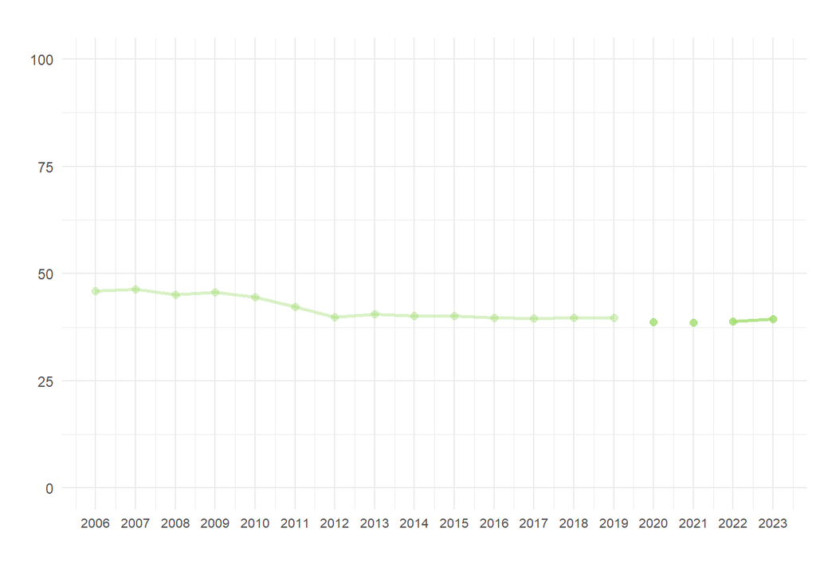

#### Tabla

|  | NOMINDICADOR | PAIS | UNIDAD_GEOGRÁFICA | ANIO | VALOR |
| --- | --- | --- | --- | --- | --- |
| 1 | Índice de Gini | Uruguay | Total País | 2006 | 45.9 |
| 2 | Índice de Gini | Uruguay | Total País | 2007 | 46.4 |
| 3 | Índice de Gini | Uruguay | Total País | 2008 | 45.1 |
| 4 | Índice de Gini | Uruguay | Total País | 2009 | 45.6 |
| 5 | Índice de Gini | Uruguay | Total País | 2010 | 44.5 |
| 6 | Índice de Gini | Uruguay | Total País | 2011 | 42.2 |
| 7 | Índice de Gini | Uruguay | Total País | 2012 | 39.9 |
| 8 | Índice de Gini | Uruguay | Total País | 2013 | 40.5 |
| 9 | Índice de Gini | Uruguay | Total País | 2014 | 40.1 |
| 10 | Índice de Gini | Uruguay | Total País | 2015 | 40.2 |

[output cut: 8 more lines]

#### Ficha Técnica

> **Definición:** El índice de Gini mide hasta qué punto la distribución del ingreso (o, en algunos casos, el gasto de consumo) entre individuos u hogares dentro de una economía se aleja de una distribución perfectamente equitativa. Una curva de Lorenz muestra los porcentajes acumulados de ingreso recibido total contra la cantidad acumulada de receptores, empezando a partir de la persona o el hogar más pobre. El índice de Gini mide la superficie entre la curva de Lorenz y una línea hipotética de equidad absoluta, expresada como porcentaje de la superficie máxima debajo de la línea. Así, un índice de Gini de 0 representa una equidad perfecta, mientras que un índice de 100 representa una inequidad perfecta.

> **Forma de cálculo:** Coeficiente entre el área delimitada entre la línea de perfecta igualdad y la curva de Lorenz y el área debajo de la línea de perfecta igualdad.

> **Advertencia:** Desde marzo de 2020 hasta junio de 2021 se interrumpió el relevamiento presencial y se aplicó de manera telefónica un cuestionario restringido con el objetivo de continuar publicando los indicadores de ingresos y mercado de trabajo. En ese período la encuesta pasó a ser de paneles rotativos elegidos al azar a partir de los casos respondentes del año anterior. En julio de 2021 el INE retomó la realización de encuestas presenciales, pero introdujo un cambio metodológico, ya que la ECH pasa a ser una encuesta de panel rotativo con periodicidad mensual compuesta por seis paneles o grupos de rotación, cada uno de los cuales es una muestra representativa de la población. Con esta nueva metodología, cada hogar seleccionado participa durante seis meses de la ECH. A partir de 2022 el indicador se calcula a partir de la base de implantación anual.

Fuente: Unidad de Métodos y Acceso a Datos (UMAD) (FCS-UdelaR) con base en Indicadores de la distribución del ingreso - Instituto Nacional de Estadística

Notas: La transparencia de colores representa cambios metodológicos en el relevamiento de las ECH. La línea se discontinúa en aquellos años en que ocurre el cambio (ver Ficha Técnica)

## **Relación de ingreso medio**

##### **Relación entre el ingreso medio per-cápita del primer y quinto quintil**

##### País Urbano, 1998 - 2024

#### Gráfico

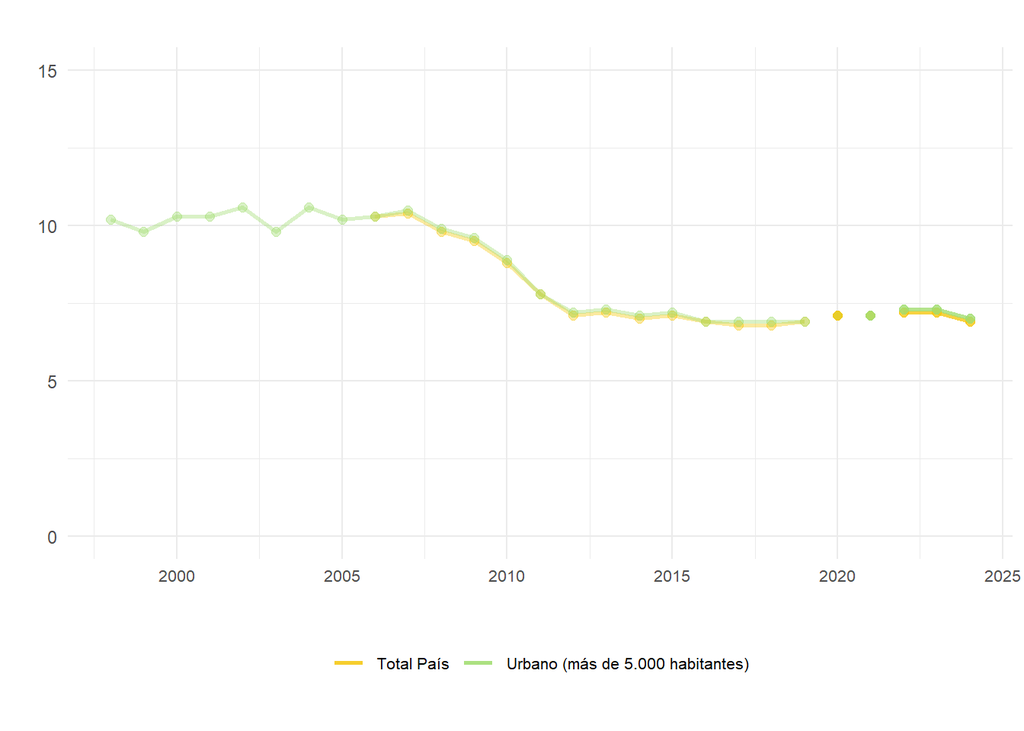

#### Tabla

|  | NOMINDICADOR | PAIS | UNIDAD_GEOGRÁFICA | ANIO | VALOR |
| --- | --- | --- | --- | --- | --- |
| 1 | Relación entre el Ingreso medio per cápita del primer y quinto quintil | Uruguay | Urbano (más de 5.000 habitantes) | 1998 | 10.2 |
| 2 | Relación entre el Ingreso medio per cápita del primer y quinto quintil | Uruguay | Urbano (más de 5.000 habitantes) | 1999 | 9.8 |
| 3 | Relación entre el Ingreso medio per cápita del primer y quinto quintil | Uruguay | Urbano (más de 5.000 habitantes) | 2000 | 10.3 |
| 4 | Relación entre el Ingreso medio per cápita del primer y quinto quintil | Uruguay | Urbano (más de 5.000 habitantes) | 2001 | 10.3 |
| 5 | Relación entre el Ingreso medio per cápita del primer y quinto quintil | Uruguay | Urbano (más de 5.000 habitantes) | 2002 | 10.6 |
| 6 | Relación entre el Ingreso medio per cápita del primer y quinto quintil | Uruguay | Urbano (más de 5.000 habitantes) | 2003 | 9.8 |
| 7 | Relación entre el Ingreso medio per cápita del primer y quinto quintil | Uruguay | Urbano (más de 5.000 habitantes) | 2004 | 10.6 |
| 8 | Relación entre el Ingreso medio per cápita del primer y quinto quintil | Uruguay | Urbano (más de 5.000 habitantes) | 2005 | 10.2 |
| 9 | Relación entre el Ingreso medio per cápita del primer y quinto quintil | Uruguay | Total País | 2006 | 10.3 |
| 10 | Relación entre el Ingreso medio per cápita del primer y quinto quintil | Uruguay | Urbano (más de 5.000 habitantes) | 2006 | 10.3 |

[output cut: 36 more lines]

#### Ficha Técnica

> **Definición:** Cociente que refleja cuantas veces mayor es el ingreso medio del 20% más rico de las personas, en relación con el del 20% más pobre.

> **Advertencia:** Desde marzo de 2020 hasta junio de 2021 se interrumpió el relevamiento presencial y se aplicó de manera telefónica un cuestionario restringido con el objetivo de continuar publicando los indicadores de ingresos y mercado de trabajo. En ese período la encuesta pasó a ser de paneles rotativos elegidos al azar a partir de los casos respondentes del año anterior. En julio de 2021 el INE retomó la realización de encuestas presenciales, pero introdujo un cambio metodológico, ya que la ECH pasa a ser una encuesta de panel rotativo con periodicidad mensual compuesta por seis paneles o grupos de rotación, cada uno de los cuales es una muestra representativa de la población. Con esta nueva metodología, cada hogar seleccionado participa durante seis meses de la ECH. A partir de 2022 el indicador se calcula a partir de la base de implantación anual.

#### Código en R

```r
### Estimación de valores 2022 ###

# Para sintaxix de años anteriores consultar:
# https://osf.io/dyzg8/files/osfstorage#

# ~~~~~~~~~~~~~~~~~~~~~~~~~~~~~~~~~~~~~~~~~~~~~~~~~~~~~~~~~~~~~~~~~~~~~~~~~~~ #

### Carga de paquetes ###

# Instalar si es necesario:
#install.packages("rio")
#install.packages("srvyr")
#install.packages("tidyverse")

library(rio)
library(srvyr)
library(tidyverse)


# ~~~~~~~~~~~~~~~~~~~~~~~~~~~~~~~~~~~~~~~~~~~~~~~~~~~~~~~~~~~~~~~~~~~~~~~~~~~ #

### Descarga bases ECH 2022 (INE) de repositorio UMAD-FCS ###

#download.file(
#  url = "https://osf.io/download/rehz2/",
#  destfile = "Base anual 2022.Rdata"
#)

# ~~~~~~~~~~~~~~~~~~~~~~~~~~~~~~~~~~~~~~~~~~~~~~~~~~~~~~~~~~~~~~~~~~~~~~~~~~~ #

### Carga de bases ###

#load("Base anual 2022.Rdata")

# ~~~~~~~~~~~~~~~~~~~~~~~~~~~~~~~~~~~~~~~~~~~~~~~~~~~~~~~~~~~~~~~~~~~~~~~~~~~ #


## Generación de nuevas variables ###

#IPC

base <- base %>% dplyr::mutate(bc_ipc_tot = case_when(
  mes == 1  ~ 0.310804203,
  mes == 2  ~ 0.305354401,
  mes == 3  ~ 0.300928439,
  mes == 4  ~ 0.297635795,
  mes == 5  ~ 0.296181029,
  mes == 6  ~ 0.294810362,
  mes == 7  ~ 0.293094596,
  mes == 8  ~ 0.290852868,
  mes == 9  ~ 0.288466429,
  mes == 10 ~ 0.286063926,
  mes == 11 ~ 0.28546134,
  mes == 12 ~ 0.286262936))


# Ingresos

base <- base %>%
  dplyr::mutate(y_pc       =  ht11 / HT19 )
base <- base %>%
  dplyr::mutate(y_pc_svl   =  (ht11 - ht13) / HT19)
base <- base %>%
  dplyr::mutate(y_pc_d     =  (ht11 / HT19) * bc_ipc_tot)
base <- base %>%
  dplyr::mutate(y_pc_svl_d =  (ht11 - ht13) / HT19 * bc_ipc_tot)

# Región

base <- base %>%
  dplyr::mutate(bd_region = case_when(region_4 == 1 | region_4 == 2 ~ 1,
                                      region_4 == 3 ~ 2,
                                      region_4 == 4 ~ 3))

# ~~~~~~~~~~~~~~~~~~~~~~~~~~~~~~~~~~~~~~~~~~~~~~~~~~~~~~~~~~~~~~~~~~~~~~~~~~~ #

### Bases a nivel hogar ###

base_h <- base %>% distinct(ID, .keep_all = TRUE)


# ~~~~~~~~~~~~~~~~~~~~~~~~~~~~~~~~~~~~~~~~~~~~~~~~~~~~~~~~~~~~~~~~~~~~~~~~~~~ #

### Información de muestreo ###

base_svy           <- srvyr::as_survey_design(base,
                                              ids = ID,
                                              weights = w_ano)

base_h_svy         <- srvyr::as_survey_design(base_h,
                                              ids = ID,
                                              weights = w_ano)

# ~~~~~~~~~~~~~~~~~~~~~~~~~~~~~~~~~~~~~~~~~~~~~~~~~~~~~~~~~~~~~~~~~~~~~~~~~~~ #

### Estimación de indicadores ###


###  Relación entre el Ingreso medio per cápita del primer y décimo decil


a_decil <- function(x) {
  x <- base_h_svy %>%
    filter(decilesy_obs == x & bd_region == 1) %>%
    srvyr::summarise(colname = srvyr::survey_mean(y_pc))
  x <- mean(x$colname)
}

a_e_decil <- numeric()

for(i in 1:10){
  a_e_decil[i] <- a_decil(x = i)
}

c_decil <- as.data.frame(a_e_decil)
m133_pu <- c_decil/sum(c_decil)

estimacion2022 <- c_decil_pu[10,1]/c_decil_pu[1,1]


# ~~~~~~~~~~~~~~~~~~~~~~~~~~~~~~~~~~~~~~~~~~~~~~~~~~~~~~~~~~~~~~~~~~~~~~~~~~~ #
```

Fuente: Unidad de Métodos y Acceso a Datos (UMAD) (FCS-UdelaR) con base en Observatorio Social, Ministerio de Desarrollo Social, a partir de la Encuesta Continua de Hogares (ECH) del Instituto Nacional de Estadística (INE)

Notas: La transparencia de colores representa cambios metodológicos en el relevamiento de las ECH. La línea se discontinúa en aquellos años en que ocurre el cambio (ver Ficha Técnica)

# **Pobreza monetaria**

## **Tasa de recuento**

La medida de pobreza más simple y más ampliamente utilizada es la tasa de recuento, que es el porcentaje de pobres en una población dada. La construcción de la línea de pobreza (LP) se basa en la definición de un umbral de ingresos necesarios para cubrir una Canasta Básica Total (CBT). Para su cálculo, se utilizan índices de precios tanto de bienes alimentarios como no alimentarios. Para determinar la LP se introducen economías de escala en los gastos no alimentarios para los estratos de referencia seleccionados en las diferentes regiones geográficas, tomando en cuenta el tamaño del hogar (INE, 2015). La línea de indigencia refiere al ingreso necesario para cubrir los gastos únicamente alimentarios.

Los siguientes gráficos muestran la evolución de ambos indicadores como proporción de hogares en condición de pobreza e indigencia y porcentaje de personas que en los mismos residen. Los mismos muestran cómo desde el 2006 la pobreza monetaria ha caído sostenidamente en Uruguay. Si se observasen registros de años anteriores se podría observar cómo, luego de más de una década de aumento en su incidencia, intensidad y severidad, es a partir del año 2005 en que se registra un punto de inflexión en la tendencia (INE, 2011). En un contexto de fuerte expansión económica, el crecimiento del empleo y los ingresos, así como la instauración de un conjunto de políticas redistributivas, han contribuido a la mejora de los indicadores de pobreza (Amarante et al., 2011). En 2020 se observa un aumento de la pobreza y de la indigencia y una posterior disminución, aunque manteniéndose en niveles superiores a los observados en los últimos 5 años.

Para 2024, se incorpora también la prevalencia de la pobreza según la metodología del INE-2017.

##### **Hogares y personas en situación de pobreza (met. 2006 y met.2017) (% de la población total)**

##### Total país, 2006 - 2024

#### Gráfico

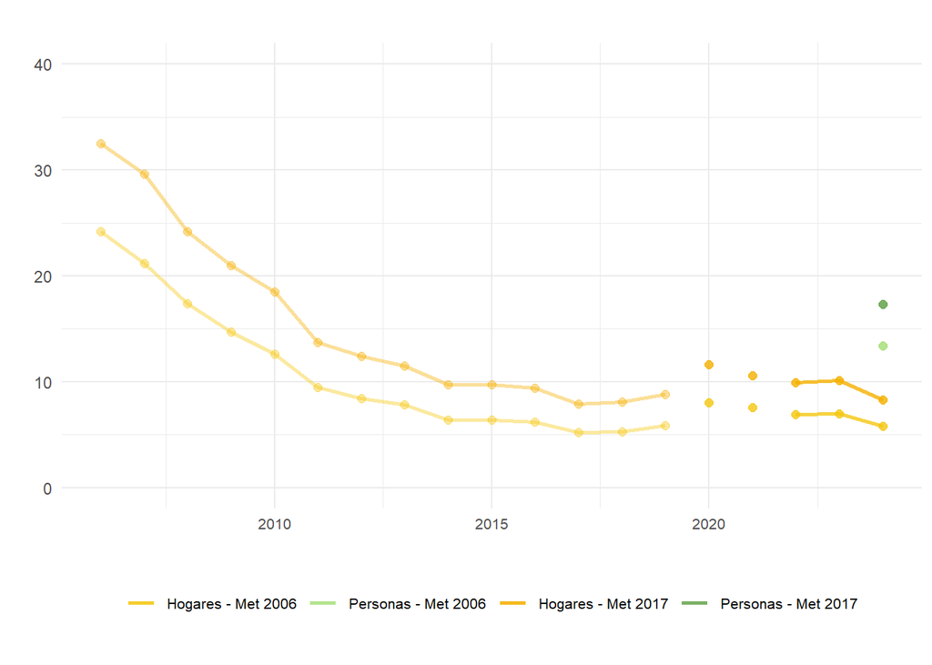

#### Tabla

|  | UNIDAD | PAIS | UNIDAD_GEOGRÁFICA | ANIO | VALOR |
| --- | --- | --- | --- | --- | --- |
| 1 | Porcentaje de hogares en situación de pobreza - Met 2006 | Uruguay | Total País | 2006 | 24.2 |
| 2 | Porcentaje de hogares en situación de pobreza - Met 2006 | Uruguay | Total País | 2007 | 21.2 |
| 3 | Porcentaje de hogares en situación de pobreza - Met 2006 | Uruguay | Total País | 2008 | 17.4 |
| 4 | Porcentaje de hogares en situación de pobreza - Met 2006 | Uruguay | Total País | 2009 | 14.7 |
| 5 | Porcentaje de hogares en situación de pobreza - Met 2006 | Uruguay | Total País | 2010 | 12.6 |
| 6 | Porcentaje de hogares en situación de pobreza - Met 2006 | Uruguay | Total País | 2011 | 9.5 |
| 7 | Porcentaje de hogares en situación de pobreza - Met 2006 | Uruguay | Total País | 2012 | 8.4 |
| 8 | Porcentaje de hogares en situación de pobreza - Met 2006 | Uruguay | Total País | 2013 | 7.8 |
| 9 | Porcentaje de hogares en situación de pobreza - Met 2006 | Uruguay | Total País | 2014 | 6.4 |
| 10 | Porcentaje de hogares en situación de pobreza - Met 2006 | Uruguay | Total País | 2015 | 6.4 |

[output cut: 30 more lines]

#### Ficha Técnica

> **Definición:** La pobreza indica la carencia de ingresos suficientes respecto de un umbral de ingreso absoluto, o línea de pobreza, que corresponde al costo de una canasta de consumo básico. Este indicador presenta el porcentaje de hogares cuyo ingreso per cápita es inferior a la línea de pobreza (metodología INE 2006).

> **Forma de cálculo:** Cantidad de hogares con ingreso per cápita inferior a la línea de pobreza/Cantidad total de hogares*100

> **Advertencia:** Desde marzo de 2020 hasta junio de 2021 se interrumpió el relevamiento presencial y se aplicó de manera telefónica un cuestionario restringido con el objetivo de continuar publicando los indicadores de ingresos y mercado de trabajo. En ese período la encuesta pasó a ser de paneles rotativos elegidos al azar a partir de los casos respondentes del año anterior. En julio de 2021 el INE retomó la realización de encuestas presenciales, pero introdujo un cambio metodológico, ya que la ECH pasa a ser una encuesta de panel rotativo con periodicidad mensual compuesta por seis paneles o grupos de rotación, cada uno de los cuales es una muestra representativa de la población. Con esta nueva metodología, cada hogar seleccionado participa durante seis meses de la ECH. A partir de 2022 el indicador se calcula a partir de la base de implantación anual.

#### Código en R

```r
### Estimación de valores 2022 ###

# Para sintaxix de años anteriores consultar:
# https://osf.io/dyzg8/files/osfstorage#

# ~~~~~~~~~~~~~~~~~~~~~~~~~~~~~~~~~~~~~~~~~~~~~~~~~~~~~~~~~~~~~~~~~~~~~~~~~~~ #

### Carga de paquetes ###

# Instalar si es necesario:
#install.packages("rio")
#install.packages("srvyr")
#install.packages("tidyverse")

library(rio)
library(srvyr)
library(tidyverse)


# ~~~~~~~~~~~~~~~~~~~~~~~~~~~~~~~~~~~~~~~~~~~~~~~~~~~~~~~~~~~~~~~~~~~~~~~~~~~ #

### Descarga bases ECH 2022 (INE) de repositorio UMAD-FCS ###

#download.file(
#  url = "https://osf.io/download/rehz2/",
#  destfile = "Base anual 2022.Rdata"
#)

# ~~~~~~~~~~~~~~~~~~~~~~~~~~~~~~~~~~~~~~~~~~~~~~~~~~~~~~~~~~~~~~~~~~~~~~~~~~~ #

### Carga de bases ###

#load("Base anual 2022.Rdata")

# ~~~~~~~~~~~~~~~~~~~~~~~~~~~~~~~~~~~~~~~~~~~~~~~~~~~~~~~~~~~~~~~~~~~~~~~~~~~ #


# ~~~~~~~~~~~~~~~~~~~~~~~~~~~~~~~~~~~~~~~~~~~~~~~~~~~~~~~~~~~~~~~~~~~~~~~~~~~ #

### Bases a nivel hogar ###

base_h <- base %>% distinct(ID, .keep_all = TRUE)

# ~~~~~~~~~~~~~~~~~~~~~~~~~~~~~~~~~~~~~~~~~~~~~~~~~~~~~~~~~~~~~~~~~~~~~~~~~~~ #

### Información de muestreo ###

base_svy           <- srvyr::as_survey_design(base,
                                              ids = ID,
                                              weights = w_ano)

base_h_svy         <- srvyr::as_survey_design(base_h,
                                              ids = ID,
                                              weights = w_ano)


# ~~~~~~~~~~~~~~~~~~~~~~~~~~~~~~~~~~~~~~~~~~~~~~~~~~~~~~~~~~~~~~~~~~~~~~~~~~~ #

### Estimación de indicadores ###


###  Hogares en situación de pobreza (% de la población total) (INE)


a_ano <- base_h_svy %>%
  srvyr::summarise(colname = srvyr::survey_mean(pobre))

a_ano <- mean(as.numeric(a_ano$colname))

estimacion2022 <- a_ano

###     Personas en situación de pobreza (% de la población total) (INE)

a_ano <- base_svy %>%
  srvyr::summarise(colname = srvyr::survey_mean(pobre))

a_ano <- mean(as.numeric(a_ano$colname))

estimacion2022 <- a_ano

# ~~~~~~~~~~~~~~~~~~~~~~~~~~~~~~~~~~~~~~~~~~~~~~~~~~~~~~~~~~~~~~~~~~~~~~~~~~~ #
```

Fuente: Unidad de Métodos y Acceso a Datos (UMAD) (FCS-UdelaR) con base en Encuesta Continua de Hogares (ECH) del Instituto Nacional de Estadística (INE) compatibilizada por el Instituto de Economía (IECON) (versión 2019) y ECH-INE 2020 y 2021.

Notas: La transparencia de colores representa cambios metodológicos en el relevamiento de las ECH. La línea se discontinúa en aquellos años en que ocurre el cambio (ver Ficha Técnica)

##### **Hogares y personas en situación de indigencia (met. 2006) (% de la población total)**

##### Total país, 2006 - 2024

#### Gráfico

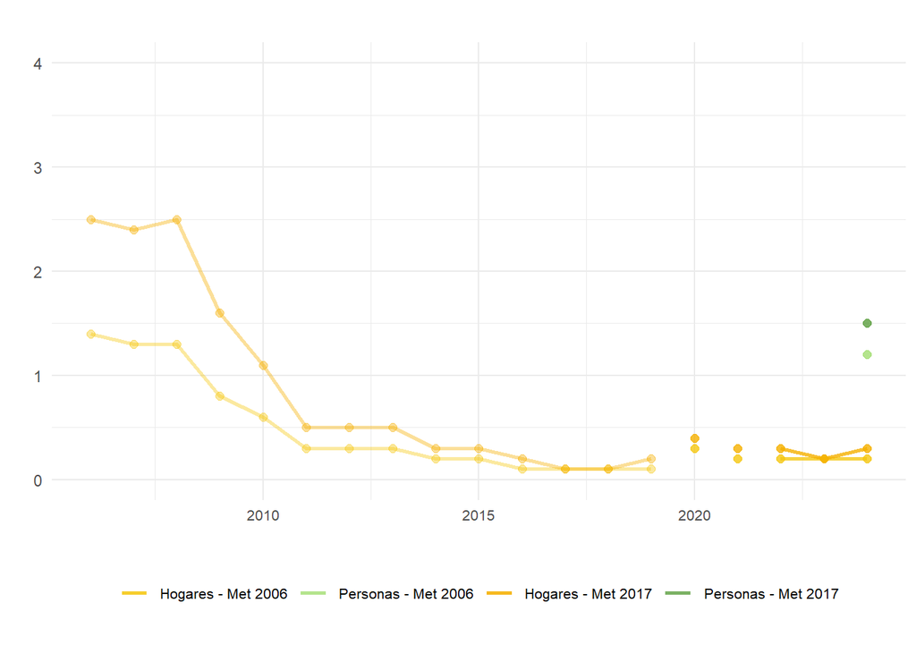

#### Tabla

|  | UNIDAD | PAIS | UNIDAD_GEOGRÁFICA | ANIO | VALOR |
| --- | --- | --- | --- | --- | --- |
| 1 | Porcentaje de hogares en situación de indigencia - Met 2006 | Uruguay | Total País | 2006 | 1.4 |
| 2 | Porcentaje de hogares en situación de indigencia - Met 2006 | Uruguay | Total País | 2007 | 1.3 |
| 3 | Porcentaje de hogares en situación de indigencia - Met 2006 | Uruguay | Total País | 2008 | 1.3 |
| 4 | Porcentaje de hogares en situación de indigencia - Met 2006 | Uruguay | Total País | 2009 | 0.8 |
| 5 | Porcentaje de hogares en situación de indigencia - Met 2006 | Uruguay | Total País | 2010 | 0.6 |
| 6 | Porcentaje de hogares en situación de indigencia - Met 2006 | Uruguay | Total País | 2011 | 0.3 |
| 7 | Porcentaje de hogares en situación de indigencia - Met 2006 | Uruguay | Total País | 2012 | 0.3 |
| 8 | Porcentaje de hogares en situación de indigencia - Met 2006 | Uruguay | Total País | 2013 | 0.3 |
| 9 | Porcentaje de hogares en situación de indigencia - Met 2006 | Uruguay | Total País | 2014 | 0.2 |
| 10 | Porcentaje de hogares en situación de indigencia - Met 2006 | Uruguay | Total País | 2015 | 0.2 |

[output cut: 30 more lines]

#### Ficha Técnica

> **Definición:** La indigencia indica la carencia de ingresos suficientes respecto de un umbral de ingreso absoluto, o línea de indigencia que establece el umbral de ingresos en el cual estos son apenas suficientes para satisfacer los requerimientos nutricionales básicos de una familia. Este indicador presenta el porcentaje de hogares cuyo ingreso per cápita es inferior a la línea de indigencia (metodología INE 2006).

> **Forma de cálculo:** Cantidad de hogares con ingreso per cápita inferior a la LI/Cantidad total de hogares*100

> **Advertencia:** Desde marzo de 2020 hasta junio de 2021 se interrumpió el relevamiento presencial y se aplicó de manera telefónica un cuestionario restringido con el objetivo de continuar publicando los indicadores de ingresos y mercado de trabajo. En ese período la encuesta pasó a ser de paneles rotativos elegidos al azar a partir de los casos respondentes del año anterior. En julio de 2021 el INE retomó la realización de encuestas presenciales, pero introdujo un cambio metodológico, ya que la ECH pasa a ser una encuesta de panel rotativo con periodicidad mensual compuesta por seis paneles o grupos de rotación, cada uno de los cuales es una muestra representativa de la población. Con esta nueva metodología, cada hogar seleccionado participa durante seis meses de la ECH. A partir de 2022 el indicador se calcula a partir de la base de implantación anual.

#### Código en R

```r
### Estimación de valores 2022 ###

# Para sintaxix de años anteriores consultar:
# https://osf.io/dyzg8/files/osfstorage#

# ~~~~~~~~~~~~~~~~~~~~~~~~~~~~~~~~~~~~~~~~~~~~~~~~~~~~~~~~~~~~~~~~~~~~~~~~~~~ #

### Carga de paquetes ###

# Instalar si es necesario:
#install.packages("rio")
#install.packages("srvyr")
#install.packages("tidyverse")

library(rio)
library(srvyr)
library(tidyverse)


# ~~~~~~~~~~~~~~~~~~~~~~~~~~~~~~~~~~~~~~~~~~~~~~~~~~~~~~~~~~~~~~~~~~~~~~~~~~~ #

### Descarga bases ECH 2022 (INE) de repositorio UMAD-FCS ###

#download.file(
#  url = "https://osf.io/download/rehz2/",
#  destfile = "Base anual 2022.Rdata"
#)

# ~~~~~~~~~~~~~~~~~~~~~~~~~~~~~~~~~~~~~~~~~~~~~~~~~~~~~~~~~~~~~~~~~~~~~~~~~~~ #

### Carga de bases ###

#load("Base anual 2022.Rdata")

# ~~~~~~~~~~~~~~~~~~~~~~~~~~~~~~~~~~~~~~~~~~~~~~~~~~~~~~~~~~~~~~~~~~~~~~~~~~~ #


# ~~~~~~~~~~~~~~~~~~~~~~~~~~~~~~~~~~~~~~~~~~~~~~~~~~~~~~~~~~~~~~~~~~~~~~~~~~~ #

### Bases a nivel hogar ###

base_h <- base %>% distinct(ID, .keep_all = TRUE)


# ~~~~~~~~~~~~~~~~~~~~~~~~~~~~~~~~~~~~~~~~~~~~~~~~~~~~~~~~~~~~~~~~~~~~~~~~~~~ #

### Información de muestreo ###

base_svy           <- srvyr::as_survey_design(base,
                                              ids = ID,
                                              weights = w_ano)

base_h_svy         <- srvyr::as_survey_design(base_h,
                                              ids = ID,
                                              weights = w_ano)


# ~~~~~~~~~~~~~~~~~~~~~~~~~~~~~~~~~~~~~~~~~~~~~~~~~~~~~~~~~~~~~~~~~~~~~~~~~~~ #

### Estimación de indicadores ###


###     Hogares en situación de indigencia (% de la población total) (INE)


a_ano <- base_h_svy %>%
  srvyr::summarise(colname = srvyr::survey_mean(indig))

a_ano <- mean(as.numeric(a_ano$colname))

estimacion2022 <- a_ano

###     Personas en situación de indigencia (% de la población total) (INE)

a_ano <- base_svy %>%
  srvyr::summarise(colname = srvyr::survey_mean(indig))

a_ano <- mean(as.numeric(a_ano$colname))

estimacion2022 <- a_ano

# ~~~~~~~~~~~~~~~~~~~~~~~~~~~~~~~~~~~~~~~~~~~~~~~~~~~~~~~~~~~~~~~~~~~~~~~~~~~ #
```

Fuente: Unidad de Métodos y Acceso a Datos (UMAD) (FCS-UdelaR) con base en Encuesta Continua de Hogares (ECH) del Instituto Nacional de Estadística (INE) compatibilizada por el Instituto de Economía (IECON) (versión 2019) y ECH-INE 2020 y 2021.

Notas: La transparencia de colores representa cambios metodológicos en el relevamiento de las ECH. La línea se discontinúa en aquellos años en que ocurre el cambio (ver Ficha Técnica)

## **Severidad de la pobreza**

La severidad de la pobreza mide el grado de desigualdad entre los hogares o personas bajo la línea de pobreza. De algún modo brinda indicios sobre la heterogeneidad u homogeneidad de quienes se encuentran en situación de pobreza. A partir del año 2006 se observa en Uruguay una disminución en su severidad y tendencia a la homogeneidad entre estos hogares.

##### **Severidad de la pobreza**

##### Total país, 2006 - 2023

#### Gráfico

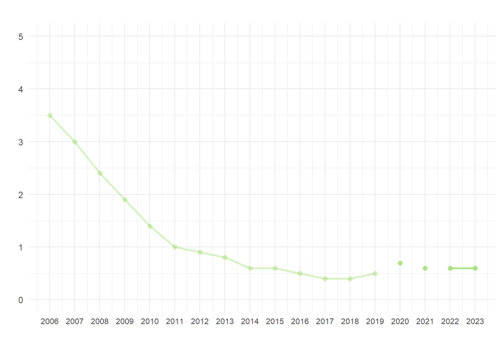

#### Tabla

|  | NOMINDICADOR | PAIS | UNIDAD_GEOGRÁFICA | ANIO | VALOR |
| --- | --- | --- | --- | --- | --- |
| 1 | Severidad de la pobreza | Uruguay | Total País | 2006 | 3.5 |
| 2 | Severidad de la pobreza | Uruguay | Total País | 2007 | 3 |
| 3 | Severidad de la pobreza | Uruguay | Total País | 2008 | 2.4 |
| 4 | Severidad de la pobreza | Uruguay | Total País | 2009 | 1.9 |
| 5 | Severidad de la pobreza | Uruguay | Total País | 2010 | 1.4 |
| 6 | Severidad de la pobreza | Uruguay | Total País | 2011 | 1 |
| 7 | Severidad de la pobreza | Uruguay | Total País | 2012 | 0.9 |
| 8 | Severidad de la pobreza | Uruguay | Total País | 2013 | 0.8 |
| 9 | Severidad de la pobreza | Uruguay | Total País | 2014 | 0.6 |
| 10 | Severidad de la pobreza | Uruguay | Total País | 2015 | 0.6 |

[output cut: 8 more lines]

#### Ficha Técnica

> **Definición:** La severidad de la pobreza mide el grado de desigualdad entre los hogares o personas bajo la línea de pobreza (línea de pobreza). De algún modo brinda indicios sobre la heterogeneidad u homogeneidad de quienes se encuentran en situación de pobreza.

> **Advertencia:** Desde marzo de 2020 hasta junio de 2021 se interrumpió el relevamiento presencial y se aplicó de manera telefónica un cuestionario restringido con el objetivo de continuar publicando los indicadores de ingresos y mercado de trabajo. En ese período la encuesta pasó a ser de paneles rotativos elegidos al azar a partir de los casos respondentes del año anterior. En julio de 2021 el INE retomó la realización de encuestas presenciales, pero introdujo un cambio metodológico, ya que la ECH pasa a ser una encuesta de panel rotativo con periodicidad mensual compuesta por seis paneles o grupos de rotación, cada uno de los cuales es una muestra representativa de la población. Con esta nueva metodología, cada hogar seleccionado participa durante seis meses de la ECH. A partir de 2022 el indicador se calcula a partir de la base de implantación anual.

Fuente: Unidad de Métodos y Acceso a Datos (UMAD) (FCS-UdelaR) con base en Indicadores de la distribución del ingreso - Instituto Nacional de Estadística

Notas: La transparencia de colores representa cambios metodológicos en el relevamiento de las ECH. La línea se discontinúa en aquellos años en que ocurre el cambio (ver Ficha Técnica)

# **Necesidades básicas**

## **Metodología 2011**

El método de las Necesidades Básicas Insatisfechas (NBI) se orienta a identificar la falta de acceso a bienes y servicios (o problemas críticos en cuanto a la calidad de aquellos) cuya disposición constituye una condición para el ejercicio de derechos sociales. El mismo requiere la definición, tanto de las necesidades como de la fijación de los umbrales por debajo de los cuales se define la privación. Estas definiciones se han ido modificando a lo largo de los años. Una de las causas fundamentales tiene que ver con el carácter histórico de la definición. Es decir, aquellos bienes y servicios considerados necesarios en un momento histórico puede variar y ser re-definido. La definición de estos indicadores suele realizarse a partir de los relevamientos de los Censos de Población. Existen diferentes definiciones en Uruguay incluidos en la medición a partir de los Censos de 1985 (DGEC, 1990), 1996 (Calvo y Giraldez, 2000) y 2011 (Calvo et. al., 2013).

Se presenta aquí la evolución de los indicadores de NBI con la metodología aplicada para los Censos 2011, a partir de la disponibilidad de información proveniente de las Encuestas Continuas de Hogares. El siguiente gráfico muestra una tendencia decreciente, tanto del porcentaje de hogares con NBI como de personas que en ellos residen desde el año 2006.

##### Total país, 2006 - 2024

#### Gráfico

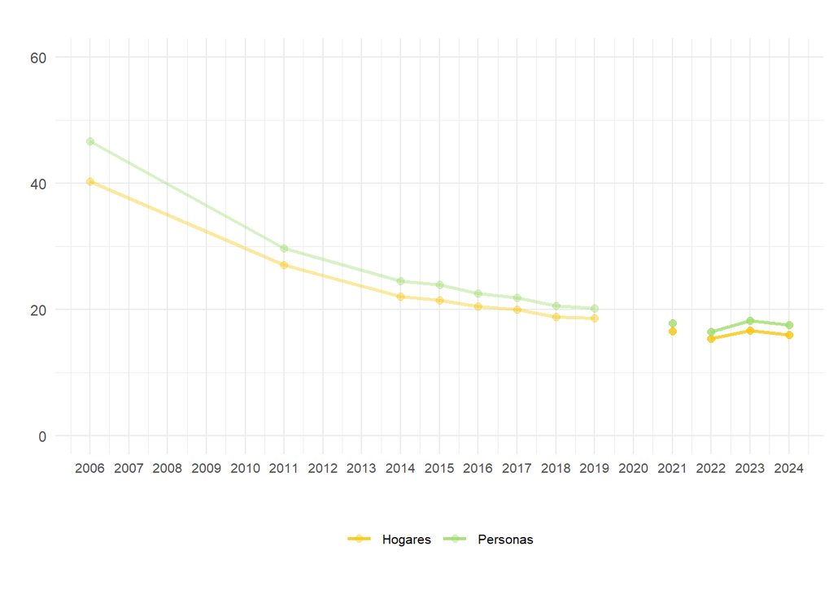

#### Tabla

|  | NOMINDICADOR | PAIS | UNIDAD_GEOGRÁFICA | ANIO | VALOR |
| --- | --- | --- | --- | --- | --- |
| 1 | Hogares con necesidades básicas insatisfechas (met 2011)(% de la población total) | Uruguay | Total País | 2006 | 40.3 |
| 2 | Hogares con necesidades básicas insatisfechas (met 2011)(% de la población total) | Uruguay | Total País | 2011 | 27.1 |
| 3 | Hogares con necesidades básicas insatisfechas (met 2011)(% de la población total) | Uruguay | Total País | 2014 | 22.1 |
| 4 | Hogares con necesidades básicas insatisfechas (met 2011)(% de la población total) | Uruguay | Total País | 2015 | 21.5 |
| 5 | Hogares con necesidades básicas insatisfechas (met 2011)(% de la población total) | Uruguay | Total País | 2016 | 20.5 |
| 6 | Hogares con necesidades básicas insatisfechas (met 2011)(% de la población total) | Uruguay | Total País | 2017 | 20 |
| 7 | Hogares con necesidades básicas insatisfechas (met 2011)(% de la población total) | Uruguay | Total País | 2018 | 18.8 |
| 8 | Hogares con necesidades básicas insatisfechas (met 2011)(% de la población total) | Uruguay | Total País | 2019 | 18.6 |
| 9 | Hogares con necesidades básicas insatisfechas (met 2011)(% de la población total) | Uruguay | Total País | 2021 | 16.6 |
| 10 | Personas en hogares con necesidades básicas insatisfechas (met 2011) (% de la población total) (INE) | Uruguay | Total País | 2006 | 46.7 |

[output cut: 14 more lines]

#### Ficha Técnica

> **Definición:** El método de las Necesidades Básicas Insatisfechas (NBI) se encuadra dentro de los llamados métodos directos de medición de la pobreza con un enfoque multidimensional. Se orienta a identificar la falta de acceso a bienes y servicios (o problemas críticos en cuanto a la calidad de aquellos) cuya disposición constituye una condición para el ejercicio de derechos sociales.

> **Forma de cálculo:** Porcentaje de hogares que presenta por lo menos una necesidad básica insatisfecha (Metodología basada en Censos 2011, INE) Referencia: Calvo, J. (Coord.) (2013) Las Necesidades Básicas Insatisfechas a partir de los Censos 2011. Atlas sociodemográfico y de la desigualdad en Uruguay. Trilce, Uruguay.

> **Advertencia:** Desde marzo de 2020 hasta junio de 2021 se interrumpió el relevamiento presencial y se aplicó de manera telefónica un cuestionario restringido con el objetivo de continuar publicando los indicadores de ingresos y mercado de trabajo. En ese período la encuesta pasó a ser de paneles rotativos elegidos al azar a partir de los casos respondentes del año anterior. En julio de 2021 el INE retomó la realización de encuestas presenciales, pero introdujo un cambio metodológico, ya que la ECH pasa a ser una encuesta de panel rotativo con periodicidad mensual compuesta por seis paneles o grupos de rotación, cada uno de los cuales es una muestra representativa de la población. Con esta nueva metodología, cada hogar seleccionado participa durante seis meses de la ECH. A partir de 2022 el indicador se calcula a partir de la base de implantación anual.

#### Código en R

```r
### Estimación de valores 2022 ###

# Para sintaxix de años anteriores consultar:
# https://osf.io/dyzg8/files/osfstorage#

# ~~~~~~~~~~~~~~~~~~~~~~~~~~~~~~~~~~~~~~~~~~~~~~~~~~~~~~~~~~~~~~~~~~~~~~~~~~~ #

### Carga de paquetes ###

# Instalar si es necesario:
#install.packages("rio")
#install.packages("srvyr")
#install.packages("tidyverse")

library(rio)
library(srvyr)
library(tidyverse)


# ~~~~~~~~~~~~~~~~~~~~~~~~~~~~~~~~~~~~~~~~~~~~~~~~~~~~~~~~~~~~~~~~~~~~~~~~~~~ #

### Descarga bases ECH 2022 (INE) de repositorio UMAD-FCS ###

#download.file(
#  url = "https://osf.io/download/rehz2/",
#  destfile = "Base anual 2022.Rdata"
#)

# ~~~~~~~~~~~~~~~~~~~~~~~~~~~~~~~~~~~~~~~~~~~~~~~~~~~~~~~~~~~~~~~~~~~~~~~~~~~ #

### Carga de bases ###

#load("Base anual 2022.Rdata")

# ~~~~~~~~~~~~~~~~~~~~~~~~~~~~~~~~~~~~~~~~~~~~~~~~~~~~~~~~~~~~~~~~~~~~~~~~~~~ #

## Generación de nuevas variables ###

# NBI - Hacinamiento
base <- base %>%
  dplyr::mutate(aux1 = HT19/d9,
       aux2 = HT19/d10,
       bd_hacinamiento1  = ifelse(aux1>2, 1, 0),
       bd_hacinamiento2  = ifelse(aux2>2, 1, 0))

# NBI - Materialidad vivienda
base <- base %>%
  dplyr::mutate(NBI_materialidad11 = ifelse(c2 == 6 | c3 == 6 | c4 == 5, 1, 0))


# NBI - Espacio apropiado para cocinar
base <- base %>%
  dplyr::mutate(bd_d19 = d19)
base <- base %>%
  dplyr::mutate(NBI_cocina11 = ifelse(bd_d19 == 3, 1, 0))


# NBI - Abastecimiento de agua potable
base <- base %>%
  dplyr::mutate(bd_d11 = case_when(d11 == 1 ~ 1,
                                   d11==2 | d11==3 ~ 2,
                                   d11>=4 & d11<=6 ~ 3))

base <- base %>%
  dplyr::mutate(bd_d12 = case_when(d12 == 1 ~ 1,
                                   d12 == 2 | d12 == 3 ~ 2,
                                   d12 == 4 ~ 3))

base <- base %>%
  dplyr::mutate(NBI_agua11 = ifelse((bd_d12 == 2 |
                                     bd_d12 == 3) |
                                     bd_d11 == 3, 1, 0))



# NBI - Servicio higiénico de calidad
base <- base %>%
  dplyr::mutate(bd_d13 = as.numeric(d13))
base <- base %>%
  dplyr::mutate(bd_d14 = as.numeric(d14))
base <- base %>%
  dplyr::mutate(bd_d15 = as.numeric(d15))
base <- base %>%
  dplyr::mutate(bd_d16 = as.numeric(case_when(d16 == 0 ~ 0,
                                              d16 == 1 ~ 1,
                                              d16 == 2 ~ 2,
                                              d16 >= 3 & d16 <= 4 ~ 3)))

base <- base %>%
  dplyr::mutate(NBI_servhigien11 = case_when(
    bd_d14 == 0 | bd_d15 == 2 | bd_d16 == 3 | bd_d16 == 4  ~ 1,
    bd_d14 != 0 & bd_d1 == 1 & (bd_d16 == 1 | bd_d16 == 2)  ~ 0,
    bd_d15 == 0 | bd_d16 == 0 ~ 99))



# NBI - Energía eléctrica
base <- base %>%
  dplyr::mutate(bd_d18 = d18)
base <- base %>%
  dplyr::mutate(NBI_energia11 = ifelse(bd_d18>2, 1, 0))


# NBI - Artefactos básicos de cofnort
base <- base %>%
  dplyr::mutate(bd_d260 = ifelse(d260 == 6, 2, 1))
base <- base %>%
  dplyr::mutate(bd_d21_1 = d21_3)
base <- base %>%
  dplyr::mutate(bd_d21_2 = case_when(d21_1 == 1 | d21_2 == 1 ~ 1,
                                     d21_1 == 2 & d21_2 == 2 ~ 2))


base <- base %>%
  dplyr::mutate(
    NBI_artefactos11 = ifelse(bd_d260 == 2 | bd_d21_1 == 2 | bd_d21_ == 2, 1, 0))


# NBI - Educación
base <- base %>% dplyr::mutate(niños_na = case_when(
  e27 <  4 | e27 >  17 ~ 0,
  e27 >= 4 & e27 <= 17 & e49 == 3 ~ 0,
  e27 >= 4 & e27 <= 17 & (e49 == 1 | e49 == 2) &
    (e201_1c == 1 | e201_1d == 1) ~ 0,
  e27 >= 4 & e27 <= 17 & (e49 == 1 | e49 == 2) &
    (e201_1c != 1 & e201_1d != 1) ~ 1))


base_niños_na <- base[,c("ID","niños_na")]
base_niños_na <- base_niños_na %>% dplyr::mutate(NBI_educacion11 = niños_na)
base_niños_na <- base_niños_na[order(base_niños_na$ID,
                                     base_niños_na$NBI_educacion11,
                                     decreasing = TRUE), ]
base_niños_na <- base_niños_na %>% distinct(ID, .keep_all = TRUE)
base_niños_na <- base_niños_na[,c("ID","NBI_educacion11")]

base <- merge(base, base_niños_na, by = "ID")



# NBI Total
base <- base %>%
  dplyr::mutate(NBI_vivienda11= ifelse(bd_hacinamiento1 == 1 |
                                         NBI_materialidad11 == 1 |
                                         NBI_cocina11 == 1, 1, 0))
base <- base %>%
  dplyr::mutate(NBI_2011= ifelse(NBI_vivienda11 == 1 |
                                 NBI_agua11 == 1 |
                                 NBI_servhigien11 == 1 |
                                 NBI_energia11 == 1 |
                                 NBI_artefactos11 == 1 |
                                 NBI_educacion11 == 1, 1, 0))

base <- base %>%
  dplyr::mutate(NBI_cant = NBI_vivienda11 +
                  NBI_agua11 +
                  NBI_servhigien11 +
                  NBI_energia11 +
                  NBI_artefactos11 +
                  NBI_educacion11)


# Región
base <- base %>%
  dplyr::mutate(bd_region = case_when(region_4 == 1 | region_4 == 2 ~ 1,
                                      region_4 == 3 ~ 2,
                                      region_4 == 4 ~ 3))


# ~~~~~~~~~~~~~~~~~~~~~~~~~~~~~~~~~~~~~~~~~~~~~~~~~~~~~~~~~~~~~~~~~~~~~~~~~~~ #

### Bases a nivel hogar ###

base_h <- base %>% distinct(ID, .keep_all = TRUE)


# ~~~~~~~~~~~~~~~~~~~~~~~~~~~~~~~~~~~~~~~~~~~~~~~~~~~~~~~~~~~~~~~~~~~~~~~~~~~ #

### Información de muestreo ###

base_svy           <- srvyr::as_survey_design(base,
                                              ids = ID,
                                              weights = w_ano)

base_h_svy         <- srvyr::as_survey_design(base_h,
                                              ids = ID,
                                              weights = w_ano)

# ~~~~~~~~~~~~~~~~~~~~~~~~~~~~~~~~~~~~~~~~~~~~~~~~~~~~~~~~~~~~~~~~~~~~~~~~~~~ #

### Estimación de indicadores ###

### Hogares con necesidades básicas insatisfechas (met 2011)(% de la población total

a_ano <- base_h_svy %>%
  srvyr::summarise(colname = srvyr::survey_mean(NBI_2011))
estimacion2022 <- as.numeric(a_ano$colname)


a_ano <- base_h_svy %>%
  srvyr::filter(bd_region == 1) %>%
  srvyr::summarise(colname = srvyr::survey_mean(NBI_2011))
estimacion2022_urb <- as.numeric(a_ano$colname)


# ~~~~~~~~~~~~~~~~~~~~~~~~~~~~~~~~~~~~~~~~~~~~~~~~~~~~~~~~~~~~~~~~~~~~~~~~~~~ #
```

Fuente: Unidad de Métodos y Acceso a Datos (UMAD) (FCS-UdelaR) con base en Encuesta Continua de Hogares (ECH) del Instituto Nacional de Estadística (INE) compatibilizada por el Instituto de Economía (IECON) (versión 2019) y ECH-INE 2020 y 2021.

Notas: La transparencia de colores representa cambios metodológicos en el relevamiento de las ECH. La línea se discontinúa en aquellos años en que ocurre el cambio (ver Ficha Técnica)

## **Hacinamiento**

##### **Personas en hogares con hacinamiento (% de la población total) (def. CELADE)**

##### País urbano, 1990 - 2024

#### Gráfico

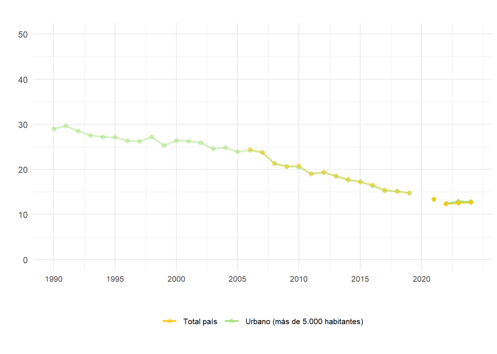

#### Tabla

|  | NOMINDICADOR | PAIS | UNIDAD_GEOGRÁFICA | ANIO | VALOR |
| --- | --- | --- | --- | --- | --- |
| 1 | Personas en hogares con hacinamiento (% de la población total) (def. CELADE) | Uruguay | Urbano (más de 5.000 habitantes) | 1990 | 29 |
| 2 | Personas en hogares con hacinamiento (% de la población total) (def. CELADE) | Uruguay | Urbano (más de 5.000 habitantes) | 1991 | 29.7 |
| 3 | Personas en hogares con hacinamiento (% de la población total) (def. CELADE) | Uruguay | Urbano (más de 5.000 habitantes) | 1992 | 28.5 |
| 4 | Personas en hogares con hacinamiento (% de la población total) (def. CELADE) | Uruguay | Urbano (más de 5.000 habitantes) | 1993 | 27.5 |
| 5 | Personas en hogares con hacinamiento (% de la población total) (def. CELADE) | Uruguay | Urbano (más de 5.000 habitantes) | 1994 | 27.2 |
| 6 | Personas en hogares con hacinamiento (% de la población total) (def. CELADE) | Uruguay | Urbano (más de 5.000 habitantes) | 1995 | 27.1 |
| 7 | Personas en hogares con hacinamiento (% de la población total) (def. CELADE) | Uruguay | Urbano (más de 5.000 habitantes) | 1996 | 26.4 |
| 8 | Personas en hogares con hacinamiento (% de la población total) (def. CELADE) | Uruguay | Urbano (más de 5.000 habitantes) | 1997 | 26.2 |
| 9 | Personas en hogares con hacinamiento (% de la población total) (def. CELADE) | Uruguay | Urbano (más de 5.000 habitantes) | 1998 | 27.2 |
| 10 | Personas en hogares con hacinamiento (% de la población total) (def. CELADE) | Uruguay | Urbano (más de 5.000 habitantes) | 1999 | 25.3 |

[output cut: 42 more lines]

#### Ficha Técnica

> **Definición:** El hacinamiento mide las carencias de espacio relativo en una vivienda.

> **Forma de cálculo:** En un hogar particular existe hacinamiento si la cantidad de personas del hogar con relación a la cantidad total de habitaciones para dormir es mayor estricto que dos.

> **Advertencia:** Desde marzo de 2020 hasta junio de 2021 se interrumpió el relevamiento presencial y se aplicó de manera telefónica un cuestionario restringido con el objetivo de continuar publicando los indicadores de ingresos y mercado de trabajo. En ese período la encuesta pasó a ser de paneles rotativos elegidos al azar a partir de los casos respondentes del año anterior. En julio de 2021 el INE retomó la realización de encuestas presenciales, pero introdujo un cambio metodológico, ya que la ECH pasa a ser una encuesta de panel rotativo con periodicidad mensual compuesta por seis paneles o grupos de rotación, cada uno de los cuales es una muestra representativa de la población. Con esta nueva metodología, cada hogar seleccionado participa durante seis meses de la ECH. A partir de 2022 el indicador se calcula a partir de la base de implantación anual.

#### Código en R

```r
### Estimación de valores 2022 ###

# Para sintaxix de años anteriores consultar:
# https://osf.io/dyzg8/files/osfstorage#

# ~~~~~~~~~~~~~~~~~~~~~~~~~~~~~~~~~~~~~~~~~~~~~~~~~~~~~~~~~~~~~~~~~~~~~~~~~~~ #

### Carga de paquetes ###

# Instalar si es necesario:
#install.packages("rio")
#install.packages("srvyr")
#install.packages("tidyverse")

library(rio)
library(srvyr)
library(tidyverse)


# ~~~~~~~~~~~~~~~~~~~~~~~~~~~~~~~~~~~~~~~~~~~~~~~~~~~~~~~~~~~~~~~~~~~~~~~~~~~ #

### Descarga bases ECH 2022 (INE) de repositorio UMAD-FCS ###

#download.file(
#  url = "https://osf.io/download/rehz2/",
#  destfile = "Base anual 2022.Rdata"
#)

# ~~~~~~~~~~~~~~~~~~~~~~~~~~~~~~~~~~~~~~~~~~~~~~~~~~~~~~~~~~~~~~~~~~~~~~~~~~~ #

### Carga de bases ###

#load("Base anual 2022.Rdata")

# ~~~~~~~~~~~~~~~~~~~~~~~~~~~~~~~~~~~~~~~~~~~~~~~~~~~~~~~~~~~~~~~~~~~~~~~~~~~ #


## Generación de nuevas variables ###


# NBI - Hacinamiento
base <- base %>%
  dplyr::mutate(aux1 = HT19/d9,
       aux2 = HT19/d10,
       bd_hacinamiento1  = ifelse(aux1>2, 1, 0),
       bd_hacinamiento2  = ifelse(aux2>2, 1, 0))

# Región
base <- base %>%
  dplyr::mutate(bd_region = case_when(region_4 == 1 | region_4 == 2 ~ 1,
                                      region_4 == 3 ~ 2,
                                      region_4 == 4 ~ 3))

# ~~~~~~~~~~~~~~~~~~~~~~~~~~~~~~~~~~~~~~~~~~~~~~~~~~~~~~~~~~~~~~~~~~~~~~~~~~~ #

### Bases a nivel hogar ###

base_h <- base %>% distinct(ID, .keep_all = TRUE)


# ~~~~~~~~~~~~~~~~~~~~~~~~~~~~~~~~~~~~~~~~~~~~~~~~~~~~~~~~~~~~~~~~~~~~~~~~~~~ #

### Información de muestreo ###

base_svy           <- srvyr::as_survey_design(base,
                                              ids = ID,
                                              weights = w_ano)

base_h_svy         <- srvyr::as_survey_design(base_h,
                                              ids = ID,
                                              weights = w_ano)

# ~~~~~~~~~~~~~~~~~~~~~~~~~~~~~~~~~~~~~~~~~~~~~~~~~~~~~~~~~~~~~~~~~~~~~~~~~~~ #

### Estimación de indicadores ###


### Hogares con hacinamiento (met 2011)(% de la población total)

a_ano <- base_h_svy %>%
  srvyr::summarise(colname = srvyr::survey_mean(bd_hacinamiento2))
estimacion2022 <- as.numeric(a_ano$colname)

a_ano <- base_h_svy %>%
  srvyr::filter(bd_region == 1) %>%
  srvyr::summarise(colname = srvyr::survey_mean(bd_hacinamiento2))
estimacion2022_urb <- as.numeric(a_ano$colname)

# ~~~~~~~~~~~~~~~~~~~~~~~~~~~~~~~~~~~~~~~~~~~~~~~~~~~~~~~~~~~~~~~~~~~~~~~~~~~ #
```

Fuente: Unidad de Métodos y Acceso a Datos (UMAD) (FCS-UdelaR) con base en Encuesta Continua de Hogares (ECH) del Instituto Nacional de Estadística (INE) compatibilizada por el Instituto de Economía (IECON) (versión 2019) y ECH-INE 2020 y 2021.

Notas: La transparencia de colores representa cambios metodológicos en el relevamiento de las ECH. La línea se discontinúa en aquellos años en que ocurre el cambio (ver Ficha Técnica)

## **Acceso a agua potable**

El acceso a agua potable constituye una necesidad básica para las personas. El indicador integra factores vinculados al origen del agua así como a la forma en que ella llega a la vivienda. Se registra una clara tendencia a la disminución en la proporción de hogares que no acceden a este servicio desde el año 2006.

##### **Personas en hogares sin agua potable (% de la población total)**

##### Total país, 2006 - 2024

#### Gráfico

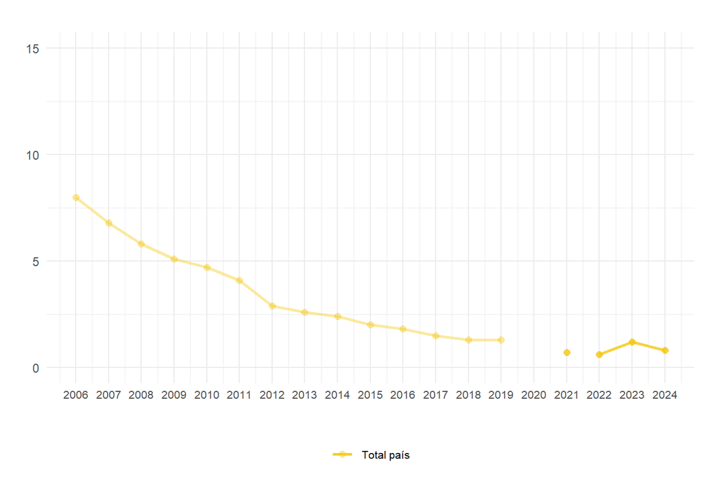

#### Tabla

|  | NOMINDICADOR | PAIS | UNIDAD_GEOGRÁFICA | ANIO | VALOR |
| --- | --- | --- | --- | --- | --- |
| 1 | Personas en hogares sin agua potable (% de la población total) | Uruguay | Total País | 2006 | 8 |
| 2 | Personas en hogares sin agua potable (% de la población total) | Uruguay | Total País | 2007 | 6.8 |
| 3 | Personas en hogares sin agua potable (% de la población total) | Uruguay | Total País | 2008 | 5.8 |
| 4 | Personas en hogares sin agua potable (% de la población total) | Uruguay | Total País | 2009 | 5.1 |
| 5 | Personas en hogares sin agua potable (% de la población total) | Uruguay | Total País | 2010 | 4.7 |
| 6 | Personas en hogares sin agua potable (% de la población total) | Uruguay | Total País | 2011 | 4.1 |
| 7 | Personas en hogares sin agua potable (% de la población total) | Uruguay | Total País | 2012 | 2.9 |
| 8 | Personas en hogares sin agua potable (% de la población total) | Uruguay | Total País | 2013 | 2.6 |
| 9 | Personas en hogares sin agua potable (% de la población total) | Uruguay | Total País | 2014 | 2.4 |
| 10 | Personas en hogares sin agua potable (% de la población total) | Uruguay | Total País | 2015 | 2 |

[output cut: 8 more lines]

#### Ficha técnica

> **Definición:** El acceso a agua potable constituye una necesidad básica para las personas. El indicador integra factores vinculados al origen del agua así como a la forma en que ella llega a la vivienda.

> **Forma de cálculo:** El hogar no accede a agua potable si la misma no llega por cañería dentro de la vivienda que habita el hogar, o su origen no es red general o pozo surgente protegido.

> **Advertencia:** Desde marzo de 2020 hasta junio de 2021 se interrumpió el relevamiento presencial y se aplicó de manera telefónica un cuestionario restringido con el objetivo de continuar publicando los indicadores de ingresos y mercado de trabajo. En ese período la encuesta pasó a ser de paneles rotativos elegidos al azar a partir de los casos respondentes del año anterior. En julio de 2021 el INE retomó la realización de encuestas presenciales, pero introdujo un cambio metodológico, ya que la ECH pasa a ser una encuesta de panel rotativo con periodicidad mensual compuesta por seis paneles o grupos de rotación, cada uno de los cuales es una muestra representativa de la población. Con esta nueva metodología, cada hogar seleccionado participa durante seis meses de la ECH. A partir de 2022 el indicador se calcula a partir de la base de implantación anual.

#### Código en R

```r
### Estimación de valores 2022 ###

# Para sintaxix de años anteriores consultar:
# https://osf.io/dyzg8/files/osfstorage#

# ~~~~~~~~~~~~~~~~~~~~~~~~~~~~~~~~~~~~~~~~~~~~~~~~~~~~~~~~~~~~~~~~~~~~~~~~~~~ #

### Carga de paquetes ###

# Instalar si es necesario:
#install.packages("rio")
#install.packages("srvyr")
#install.packages("tidyverse")

library(rio)
library(srvyr)
library(tidyverse)


# ~~~~~~~~~~~~~~~~~~~~~~~~~~~~~~~~~~~~~~~~~~~~~~~~~~~~~~~~~~~~~~~~~~~~~~~~~~~ #

### Descarga bases ECH 2022 (INE) de repositorio UMAD-FCS ###

#download.file(
#  url = "https://osf.io/download/rehz2/",
#  destfile = "Base anual 2022.Rdata"
#)

# ~~~~~~~~~~~~~~~~~~~~~~~~~~~~~~~~~~~~~~~~~~~~~~~~~~~~~~~~~~~~~~~~~~~~~~~~~~~ #

### Carga de bases ###

#load("Base anual 2022.Rdata")

# ~~~~~~~~~~~~~~~~~~~~~~~~~~~~~~~~~~~~~~~~~~~~~~~~~~~~~~~~~~~~~~~~~~~~~~~~~~~ #


## Generación de nuevas variables ###


# NBI - Abastecimiento de agua potable
base <- base %>%
  dplyr::mutate(bd_d11 = case_when(d11 == 1 ~ 1,
                                   d11==2 | d11==3 ~ 2,
                                   d11>=4 & d11<=6 ~ 3))

base <- base %>%
  dplyr::mutate(bd_d12 = case_when(d12 == 1 ~ 1,
                                   d12 == 2 | d12 == 3 ~ 2,
                                   d12 == 4 ~ 3))

base <- base %>%
  dplyr::mutate(NBI_agua11 = ifelse((bd_d12 == 2 |
                                     bd_d12 == 3) |
                                     bd_d11 == 3, 1, 0))



# ~~~~~~~~~~~~~~~~~~~~~~~~~~~~~~~~~~~~~~~~~~~~~~~~~~~~~~~~~~~~~~~~~~~~~~~~~~~ #

### Bases a nivel hogar ###

base_h <- base %>% distinct(ID, .keep_all = TRUE)


# ~~~~~~~~~~~~~~~~~~~~~~~~~~~~~~~~~~~~~~~~~~~~~~~~~~~~~~~~~~~~~~~~~~~~~~~~~~~ #

### Información de muestreo ###

base_svy           <- srvyr::as_survey_design(base,
                                              ids = ID,
                                              weights = w_ano)

base_h_svy         <- srvyr::as_survey_design(base_h,
                                              ids = ID,
                                              weights = w_ano)

# ~~~~~~~~~~~~~~~~~~~~~~~~~~~~~~~~~~~~~~~~~~~~~~~~~~~~~~~~~~~~~~~~~~~~~~~~~~~ #

### Estimación de indicadores ###


### Hogares sin acceso a agua potable (met 2011)(% de la población total)

a_ano <- base_h_svy %>%
  srvyr::summarise(colname = srvyr::survey_mean(NBI_agua11))
estimacion2022 <- as.numeric(a_ano$colname)


# ~~~~~~~~~~~~~~~~~~~~~~~~~~~~~~~~~~~~~~~~~~~~~~~~~~~~~~~~~~~~~~~~~~~~~~~~~~~ #
```

Fuente: Unidad de Métodos y Acceso a Datos (UMAD) (FCS-UdelaR) con base en Encuesta Continua de Hogares (ECH) del Instituto Nacional de Estadística (INE) compatibilizada por el Instituto de Economía (IECON) (versión 2019) y ECH-INE 2020 y 2021.

Notas: La transparencia de colores representa cambios metodológicos en el relevamiento de las ECH. La línea se discontinúa en aquellos años en que ocurre el cambio (ver Ficha Técnica)

## **Artefactos básicos de confort**

La tenencia de algunos bienes en el hogar son indicativos de la calidad de vida de las personas. Se considera que la persona posee una privación en términos de acceso a artefactos básicos de confort en base a la ausencia de medios de calefacción, para refrigerar alimentos o para disponer de agua caliente en el baño. La evolución de este indicador desde 2006 muestra una tendencia decreciente, evidenciando una mejora en la calidad de vida de las personas durante el período.

##### **Personas en hogares sin artefactos básicos de confort (% de la población total)**

##### Total país, 2006 - 2024

#### Gráfico

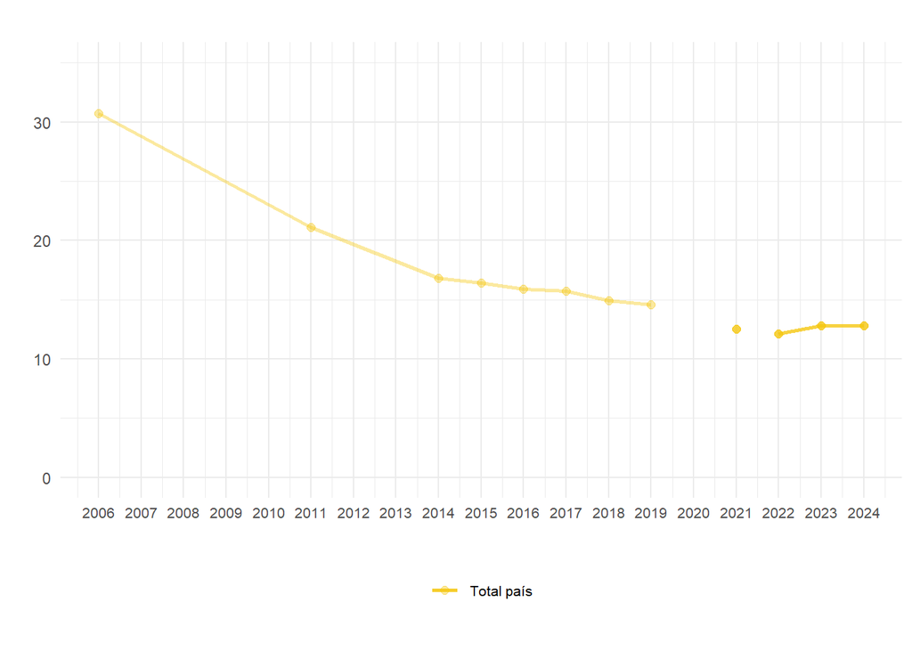

#### Tabla

|  | NOMINDICADOR | PAIS | UNIDAD_GEOGRÁFICA | ANIO | VALOR |
| --- | --- | --- | --- | --- | --- |
| 1 | Personas en hogares sin artefactos básicos de confort(% de la población total) | Uruguay | Total País | 2006 | 30.7 |
| 2 | Personas en hogares sin artefactos básicos de confort(% de la población total) | Uruguay | Total País | 2011 | 21.1 |
| 3 | Personas en hogares sin artefactos básicos de confort(% de la población total) | Uruguay | Total País | 2014 | 16.8 |
| 4 | Personas en hogares sin artefactos básicos de confort(% de la población total) | Uruguay | Total País | 2015 | 16.4 |
| 5 | Personas en hogares sin artefactos básicos de confort(% de la población total) | Uruguay | Total País | 2016 | 15.9 |
| 6 | Personas en hogares sin artefactos básicos de confort(% de la población total) | Uruguay | Total País | 2017 | 15.7 |
| 7 | Personas en hogares sin artefactos básicos de confort(% de la población total) | Uruguay | Total País | 2018 | 14.9 |
| 8 | Personas en hogares sin artefactos básicos de confort(% de la población total) | Uruguay | Total País | 2019 | 14.6 |
| 9 | Personas en hogares sin artefactos básicos de confort(% de la población total) | Uruguay | Total País | 2021 | 12.5 |
| 10 | Personas en hogares sin artefactos básicos de confort(% de la población total) | Uruguay | Total País | 2022 | 12.1 |

[output cut: 2 more lines]

#### Ficha técnica

> **Definición:** Indicador de calidad de vida de las persons. Se consiera que la persona posee una privación en términos de acceso a artefactos básicos de confort en base a la ausencia de medios de calefacción, para refrigerar alimentos o para disponer de agua caliente en el baño.

> **Forma de cálculo:** El hogar se encuentra privado de artefactos básicos de confort si: (a) El hogar no cuenta con ningún medio para calefaccionar la vivienda que habita; (b) El hogar no cuenta con heladera o freezer; o (c) El hogar no posee calefón, termofón, caldereta o calentador instantáneo.

> **Advertencia:** Desde marzo de 2020 hasta junio de 2021 se interrumpió el relevamiento presencial y se aplicó de manera telefónica un cuestionario restringido con el objetivo de continuar publicando los indicadores de ingresos y mercado de trabajo. En ese período la encuesta pasó a ser de paneles rotativos elegidos al azar a partir de los casos respondentes del año anterior. En julio de 2021 el INE retomó la realización de encuestas presenciales, pero introdujo un cambio metodológico, ya que la ECH pasa a ser una encuesta de panel rotativo con periodicidad mensual compuesta por seis paneles o grupos de rotación, cada uno de los cuales es una muestra representativa de la población. Con esta nueva metodología, cada hogar seleccionado participa durante seis meses de la ECH. A partir de 2022 el indicador se calcula a partir de la base de implantación anual.

#### Código en R

```r
### Estimación de valores 2022 ###

# Para sintaxix de años anteriores consultar:
# https://osf.io/dyzg8/files/osfstorage#

# ~~~~~~~~~~~~~~~~~~~~~~~~~~~~~~~~~~~~~~~~~~~~~~~~~~~~~~~~~~~~~~~~~~~~~~~~~~~ #

### Carga de paquetes ###

# Instalar si es necesario:
#install.packages("rio")
#install.packages("srvyr")
#install.packages("tidyverse")

library(rio)
library(srvyr)
library(tidyverse)


# ~~~~~~~~~~~~~~~~~~~~~~~~~~~~~~~~~~~~~~~~~~~~~~~~~~~~~~~~~~~~~~~~~~~~~~~~~~~ #

### Descarga bases ECH 2022 (INE) de repositorio UMAD-FCS ###

#download.file(
#  url = "https://osf.io/download/rehz2/",
#  destfile = "Base anual 2022.Rdata"
#)

# ~~~~~~~~~~~~~~~~~~~~~~~~~~~~~~~~~~~~~~~~~~~~~~~~~~~~~~~~~~~~~~~~~~~~~~~~~~~ #

### Carga de bases ###

#load("Base anual 2022.Rdata")

# ~~~~~~~~~~~~~~~~~~~~~~~~~~~~~~~~~~~~~~~~~~~~~~~~~~~~~~~~~~~~~~~~~~~~~~~~~~~ #


## Generación de nuevas variables ###


# NBI - Artefactos básicos de cofnort
base <- base %>%
  dplyr::mutate(bd_d260 = ifelse(d260 == 6, 2, 1))
base <- base %>%
  dplyr::mutate(bd_d21_1 = d21_3)
base <- base %>%
  dplyr::mutate(bd_d21_2 = case_when(d21_1 == 1 | d21_2 == 1 ~ 1,
                                     d21_1 == 2 & d21_2 == 2 ~ 2))


base <- base %>%
  dplyr::mutate(
    NBI_artefactos11 = ifelse(bd_d260 == 2 | bd_d21_1 == 2 | bd_d21_ == 2, 1, 0))



# ~~~~~~~~~~~~~~~~~~~~~~~~~~~~~~~~~~~~~~~~~~~~~~~~~~~~~~~~~~~~~~~~~~~~~~~~~~~ #

### Bases a nivel hogar ###

base_h <- base %>% distinct(ID, .keep_all = TRUE)


# ~~~~~~~~~~~~~~~~~~~~~~~~~~~~~~~~~~~~~~~~~~~~~~~~~~~~~~~~~~~~~~~~~~~~~~~~~~~ #

### Información de muestreo ###

base_svy           <- srvyr::as_survey_design(base,
                                              ids = ID,
                                              weights = w_ano)

base_h_svy         <- srvyr::as_survey_design(base_h,
                                              ids = ID,
                                              weights = w_ano)

# ~~~~~~~~~~~~~~~~~~~~~~~~~~~~~~~~~~~~~~~~~~~~~~~~~~~~~~~~~~~~~~~~~~~~~~~~~~~ #

### Estimación de indicadores ###


### Hogares sin artefactos básicos de confort (met 2011)(% de la población total

a_ano <- base_h_svy %>%
  srvyr::summarise(colname = srvyr::survey_mean(NBI_artefactos11))
estimacion2022 <- as.numeric(a_ano$colname)

# ~~~~~~~~~~~~~~~~~~~~~~~~~~~~~~~~~~~~~~~~~~~~~~~~~~~~~~~~~~~~~~~~~~~~~~~~~~~ #
```

Fuente: Unidad de Métodos y Acceso a Datos (UMAD) (FCS-UdelaR) con base en Encuesta Continua de Hogares (ECH) del Instituto Nacional de Estadística (INE) compatibilizada por el Instituto de Economía (IECON) (versión 2019) y ECH-INE 2020 y 2021.

Notas: La transparencia de colores representa cambios metodológicos en el relevamiento de las ECH. La línea se discontinúa en aquellos años en que ocurre el cambio (ver Ficha Técnica)

## **Acceso a la educación**

La educación constituye un requerimiento mínimo para que las personas puedan incorporarse adecuadamente a la vida productiva y social. En Uruguay, se establece como obligatoria la asistencia a algún centro educativo entre los 4 años y hasta la educación media superior. Se considera que un hogar presenta una carencia en el acceso a la educación si al menos un integrante del hogar con edad comprendida entre los 4 y los 17 años no se encuentra asistiendo a un centro educativo formal, no habiendo finalizado enseñanza secundaria. Desde la década del ochenta, la proporción de hogares con una carencia en este indicador disminuye sustancialmente.

##### **Personas en hogares con miembros de 4 a 17 años que no asisten a centros educativos (% de la población total)**

##### País urbano, 1981 - 2024

#### Gráfico

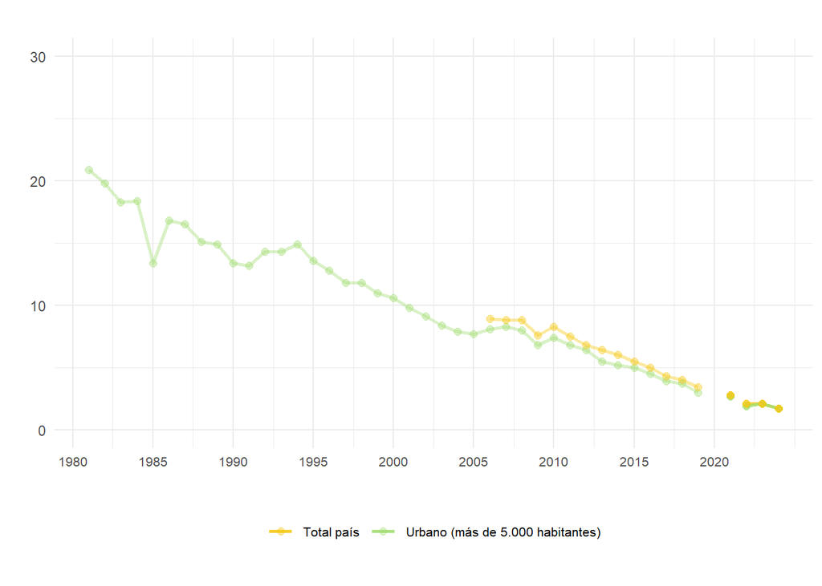

#### Tabla

|  | NOMINDICADOR | PAIS | UNIDAD_GEOGRÁFICA | ANIO | VALOR |
| --- | --- | --- | --- | --- | --- |
| 1 | Personas en hogares con miembros de 4 a 17 años que no asisten a centros educativos (% de la población total) | Uruguay | Urbano (más de 5.000 habitantes) | 1981 | 20.9 |
| 2 | Personas en hogares con miembros de 4 a 17 años que no asisten a centros educativos (% de la población total) | Uruguay | Urbano (más de 5.000 habitantes) | 1982 | 19.8 |
| 3 | Personas en hogares con miembros de 4 a 17 años que no asisten a centros educativos (% de la población total) | Uruguay | Urbano (más de 5.000 habitantes) | 1983 | 18.3 |
| 4 | Personas en hogares con miembros de 4 a 17 años que no asisten a centros educativos (% de la población total) | Uruguay | Urbano (más de 5.000 habitantes) | 1984 | 18.4 |
| 5 | Personas en hogares con miembros de 4 a 17 años que no asisten a centros educativos (% de la población total) | Uruguay | Urbano (más de 5.000 habitantes) | 1985 | 13.4 |
| 6 | Personas en hogares con miembros de 4 a 17 años que no asisten a centros educativos (% de la población total) | Uruguay | Urbano (más de 5.000 habitantes) | 1986 | 16.8 |
| 7 | Personas en hogares con miembros de 4 a 17 años que no asisten a centros educativos (% de la población total) | Uruguay | Urbano (más de 5.000 habitantes) | 1987 | 16.5 |
| 8 | Personas en hogares con miembros de 4 a 17 años que no asisten a centros educativos (% de la población total) | Uruguay | Urbano (más de 5.000 habitantes) | 1988 | 15.1 |
| 9 | Personas en hogares con miembros de 4 a 17 años que no asisten a centros educativos (% de la población total) | Uruguay | Urbano (más de 5.000 habitantes) | 1989 | 14.9 |
| 10 | Personas en hogares con miembros de 4 a 17 años que no asisten a centros educativos (% de la población total) | Uruguay | Urbano (más de 5.000 habitantes) | 1990 | 13.4 |

[output cut: 51 more lines]

#### Ficha Técnica

> **Definición:** La educación constituye un requerimiento mínimo para que las personas puedan incorporarse adecuadamente a la vida productiva y social. En Uruguay, se establece como obligatoria la asistencia a algún centro educativo entre los 4 años y hasta la educación media superior.

> **Forma de cálculo:** Al menos un integrante del hogar con edad comprendida entre los 4 y los 17 años no se encuentra asistiendo a un centro educativo formal, no habiendo finalizado enseñanza secundaria.

> **Advertencia:** Desde marzo de 2020 hasta junio de 2021 se interrumpió el relevamiento presencial y se aplicó de manera telefónica un cuestionario restringido con el objetivo de continuar publicando los indicadores de ingresos y mercado de trabajo. En ese período la encuesta pasó a ser de paneles rotativos elegidos al azar a partir de los casos respondentes del año anterior. En julio de 2021 el INE retomó la realización de encuestas presenciales, pero introdujo un cambio metodológico, ya que la ECH pasa a ser una encuesta de panel rotativo con periodicidad mensual compuesta por seis paneles o grupos de rotación, cada uno de los cuales es una muestra representativa de la población. Con esta nueva metodología, cada hogar seleccionado participa durante seis meses de la ECH. A partir de 2022 el indicador se calcula a partir de la base de implantación anual.

#### Código en R

```r
### Estimación de valores 2022 ###

# Para sintaxix de años anteriores consultar:
# https://osf.io/dyzg8/files/osfstorage#

# ~~~~~~~~~~~~~~~~~~~~~~~~~~~~~~~~~~~~~~~~~~~~~~~~~~~~~~~~~~~~~~~~~~~~~~~~~~~ #

### Carga de paquetes ###

# Instalar si es necesario:
#install.packages("rio")
#install.packages("srvyr")
#install.packages("tidyverse")

library(rio)
library(srvyr)
library(tidyverse)


# ~~~~~~~~~~~~~~~~~~~~~~~~~~~~~~~~~~~~~~~~~~~~~~~~~~~~~~~~~~~~~~~~~~~~~~~~~~~ #

### Descarga bases ECH 2022 (INE) de repositorio UMAD-FCS ###

#download.file(
#  url = "https://osf.io/download/rehz2/",
#  destfile = "Base anual 2022.Rdata"
#)

# ~~~~~~~~~~~~~~~~~~~~~~~~~~~~~~~~~~~~~~~~~~~~~~~~~~~~~~~~~~~~~~~~~~~~~~~~~~~ #

### Carga de bases ###

#load("Base anual 2022.Rdata")

# ~~~~~~~~~~~~~~~~~~~~~~~~~~~~~~~~~~~~~~~~~~~~~~~~~~~~~~~~~~~~~~~~~~~~~~~~~~~ #


## Generación de nuevas variables ###


# NBI - Educación
base <- base %>% dplyr::mutate(niños_na = case_when(
  e27 <  4 | e27 >  17 ~ 0,
  e27 >= 4 & e27 <= 17 & e49 == 3 ~ 0,
  e27 >= 4 & e27 <= 17 & (e49 == 1 | e49 == 2) &
    (e201_1c == 1 | e201_1d == 1) ~ 0,
  e27 >= 4 & e27 <= 17 & (e49 == 1 | e49 == 2) &
    (e201_1c != 1 & e201_1d != 1) ~ 1))


base_niños_na <- base[,c("ID","niños_na")]
base_niños_na <- base_niños_na %>% dplyr::mutate(NBI_educacion11 = niños_na)
base_niños_na <- base_niños_na[order(base_niños_na$ID,
                                     base_niños_na$NBI_educacion11,
                                     decreasing = TRUE), ]
base_niños_na <- base_niños_na %>% distinct(ID, .keep_all = TRUE)
base_niños_na <- base_niños_na[,c("ID","NBI_educacion11")]

base <- merge(base, base_niños_na, by = "ID")


# Región
base <- base %>%
  dplyr::mutate(bd_region = case_when(region_4 == 1 | region_4 == 2 ~ 1,
                                      region_4 == 3 ~ 2,
                                      region_4 == 4 ~ 3))

# ~~~~~~~~~~~~~~~~~~~~~~~~~~~~~~~~~~~~~~~~~~~~~~~~~~~~~~~~~~~~~~~~~~~~~~~~~~~ #

### Bases a nivel hogar ###

base_h <- base %>% distinct(ID, .keep_all = TRUE)

# ~~~~~~~~~~~~~~~~~~~~~~~~~~~~~~~~~~~~~~~~~~~~~~~~~~~~~~~~~~~~~~~~~~~~~~~~~~~ #

### Información de muestreo ###

base_svy           <- srvyr::as_survey_design(base,
                                              ids = ID,
                                              weights = w_ano)

base_h_svy         <- srvyr::as_survey_design(base_h,
                                              ids = ID,
                                              weights = w_ano)

# ~~~~~~~~~~~~~~~~~~~~~~~~~~~~~~~~~~~~~~~~~~~~~~~~~~~~~~~~~~~~~~~~~~~~~~~~~~~ #

### Estimación de indicadores ###


### Hogares sin acceso a educación (met 2011)(% de la población total

a_ano <- base_h_svy %>%
  srvyr::summarise(colname = srvyr::survey_mean(NBI_educacion11))
estimacion2022 <- as.numeric(a_ano$colname)

a_ano <- base_h_svy %>%
  srvyr::filter(bd_region == 1) %>%
  srvyr::summarise(colname = srvyr::survey_mean(NBI_educacion11))
estimacion2022_urb <- as.numeric(a_ano$colname)


# ~~~~~~~~~~~~~~~~~~~~~~~~~~~~~~~~~~~~~~~~~~~~~~~~~~~~~~~~~~~~~~~~~~~~~~~~~~~ #
```

Fuente: Unidad de Métodos y Acceso a Datos (UMAD) (FCS-UdelaR) con base en Encuesta Continua de Hogares (ECH) del Instituto Nacional de Estadística (INE) compatibilizada por el Instituto de Economía (IECON) (versión 2019) y ECH-INE 2020 y 2021.

Notas: La transparencia de colores representa cambios metodológicos en el relevamiento de las ECH. La línea se discontinúa en aquellos años en que ocurre el cambio (ver Ficha Técnica)

# **Referencias**

## **Fuentes de consulta**

[Instituto Nacional de Estadística](http://www.ine.gub.uy/)  
[Observatorio Social Mides](http://observatoriosocial.mides.gub.uy/portal/indicadores.php)  
[Cepalstat](https://estadisticas.cepal.org/cepalstat/Portada.html)  
[Wordld Development Indicators](https://databank.worldbank.org/source/world-development-indicators)  
[Banco Mundial](https://www.bancomundial.org/)

## **Referencias bibliográficas**

Alkire, Sabine y Foster, James (2008) Recuento y medición multidimensional de la pobreza. OPHI Working paper series. Disponible en: [enlace en línea](https://ophi.org.uk/recuento-y-medicion-multidimensional-de-la-pobreza/). Consultado el 13/03/2020

Amarante, Verónica (2015) La medición de la desigualdad: otros indicadores. CEPAL.

Batthyany, K. (Ed.) (2015) Los tiempos del bienestar social. Género, trabajo no remunerado y cuidados en Uruguay. Inmujeres-Mides, Uruguay.

Borrás, Victor (2017) Multidimensionalidad de la pobreza en Uruguay, 2006-2013: Análisis en cuatro dominios geográficos. Revista de Ciencias Sociales, Vol. 30. FCS-Udelar, Uruguay.

Calvo, J. (Coord.) (2013) Las Necesidades Básicas Insatisfechas a partir de los Censos 2011. Atlas sociodemográfico y de la desigualdad en Uruguay.

Colafranceschi, Marco; Failache, Elisa y Vigorito, Andrea (2013) Desigualdad multidimensional y dinámica de la pobreza en Uruguay en los años recientes. El futuro en foco. Cuadernos sobre Desarrollo Humano. PNUD, Uruguay.

Haughton, Jonathan y Khandker, Shahiur (2009) Handbook on Poverty + Inequality. The World Bank, Washington DC.

INE (2016) Estimación de la pobreza por método de ingreso. Disponible en: [enlace en línea](http://www.ine.gub.uy/documents/10181/364159/Estimaci%C3%B3n+de+la+pobreza+por+el+M%C3%A9todo+del+Ingreso+2016/4b1eabd2-ac77-48ac-95c2-fc5b92f3ade8). Consultado 13/03/2020.

Mides (2013) Avances para la medición multidimensional de la pobreza en Uruguay desde un enfoque de derechos. Documento de trabajo. Disponible en:[enlace en línea](http://dinem.mides.gub.uy/innovaportal/file/56385/1/avances-para-la-medicion-multidimensional-de-la-pobreza-en-uruguay-desde-un-enfoque-de-derechos.-2015.pdf). Consultado el 13/03/2020.

World Bank (2000) World Development Report 2000/2001: Attacking Poverty. Washington, DC: World Bank  
Sen, Amartya (1987) Commodities and Capabilities. Amsterdam: North-Holland.

## **Contacto**

Si tiene consultas, sugerencias, comentarios o encontró algún error en este documento, le agradecemos que se contacte con nosotros/as.

**Contacto: umad@cienciassociales.edu.uy**